# 1 Traveling Salesman Problem

The Traveling Salesman Problem is a classical algorithm problem. It consists in visiting a number of cities using the shortest possible route.

## 1.1 Illustration

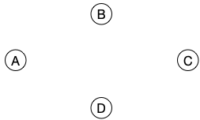

Figure 1: Illustration of the Traveling Salesman Problem.

Consider the example given in Figure 1. The figure shows four cities located as an horizontal diamond. Each city has a 2D coordinate and is therefore located in a two-dimensional plan. Assuming the traveler begins its journey in city A, many paths are possible to visit all the cities.

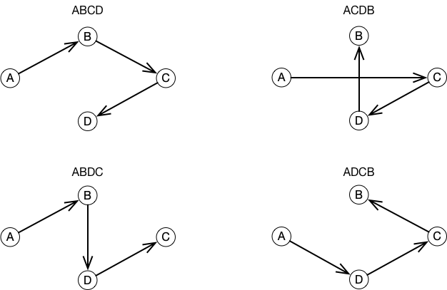

Figure 2: Illustration of the Traveling Salesman Problem.

As illustrated in Figure 2, different paths are possible, including ABCD, ABDC, ADBC, ACDB, and ADCB. *What is the shortest path to visit all the cites?* Since the distance between City B and City D is the shortest segment, the shortest path to visit all cities should necessarily contain the segment BD or DB.

## 1.2 Relevance of the Traveling Salesman Problem

The Traveling Salesman Problem (TSP) is a relevant problem to focus on, both from a theoretical and practical points of view. The TSP was formulated in the early 1930 and is among the most studied algorithmic problems. Applications of the TSP are numerous, ranging from combinatorial optimization (*i.e.,* finding an optimal object from a finite set of objects) to resource planning, DNA sequencing, and microchip manufacturing. Even though it has been studied for a long time, no general solution has been discovered yet.

TSP is apparently a simple problem: one should simply connect some cities, in an optimal way. However, TSP is a very difficult problem and is considered as *NP-hard*. Being NP-hard means that a correct solutions are easy to verify (*e.g.,* given two paths, it is easy to pick which one is shortest), but there is no efficient way to solve the problem itself. If someone, one day, finds an analytic solution to the TSP, the World is surely set to be impacted. Analytically solving an NP-hard problem means that NP-complete can also be analytically solved. Have you heard about P versus NP problems? This is one of the most challenging question mathematicians are facing today. Actually, a millennium prize of 1 000 000 USD will be given by the Clay Mathematics Institute if one solves this problem.

In this chapter we do not pretend analytically solving this problem. However, genetic algorithm is a pretty solid technique to find a good path, although no guaranty is provided on whether this path is optimal or not.

## 1.3 Naive Approach

How to encode a path to make it exploitable by a genetic algorithm? For this problem, computing the fitness is trivial: it is simply the sum of the segment lengths. We can try the following script:

```
"We encode distances"
d := { ($A -> $B) -> 10 . ($A -> $D) -> 10 . ($B -> $C) -> 10 . ($C -> $D) -> 10 . ($A -> $C) -> 20 . ($B -> $D) -> 8 } asDictionary.

g := GAEngine new.
g endIfNoImprovementFor: 10.
g populationSize: 100.
g numberOfGenes: 4.
g createGeneBlock: [ :rand :index :ind | 'ABCD' atRandom: rand ].
g minimizeComparator.
g fitnessBlock: [ :genes |
    | currentCity length |
    currentCity := genes first.
    length := 0.
    genes allButFirst do: [ :nextCity |
        length := length + (d at: (currentCity -> nextCity) ifAbsent: [ d at: (nextCity -> currentCity) ifAbsent: [ 0 ] ]).
        currentCity := nextCity ].
    length
     ].
g run
```

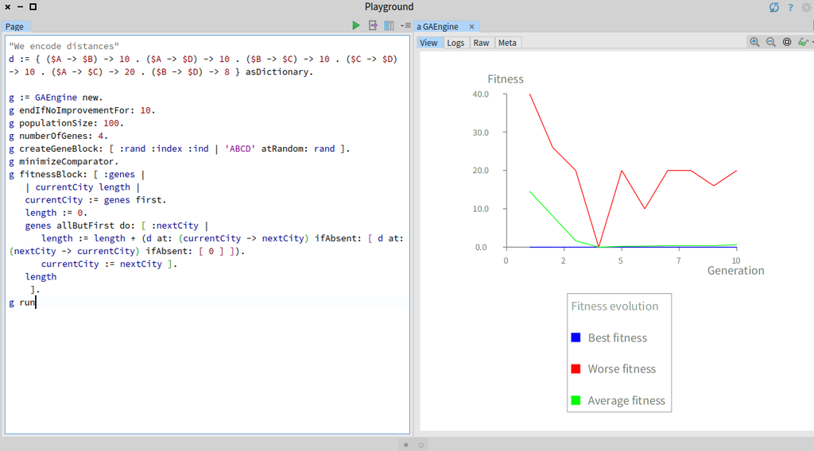

Figure 3: Result of the naive approach.

Figure 3 gives the result of the run. The best fitness is zero, which is clearly not what we expect. Pressing the `Logs` tab reveals that all the individual are `($B $B $B $B)`. The genetic algorithm found that the shortest distance is to not travel at all!

How can we force the algorithm to avoid visiting the same cities? A path, in order to be valid, should pass through all the cities once. The easiest way to enforce this, is to incur a penalty when this happens. Consider this revised script:

```
"We encode distances"
d := { ($A -> $B) -> 10 . ($A -> $D) -> 10 . ($B -> $C) -> 10 . ($C -> $D) -> 10 . ($A -> $C) -> 20 . ($B -> $D) -> 8 } asDictionary.

g := GAEngine new.
g endIfNoImprovementFor: 10.
g populationSize: 1000.
g numberOfGenes: 4.
g createGeneBlock: [ :rand :index :ind | 'ABCD' atRandom: rand ].
g minimizeComparator.
g fitnessBlock: [ :genes |
    | currentCity length |
    currentCity := genes first.
    length := 0.
    genes allButFirst do: [ :nextCity |
        length := length + (d at: (currentCity -> nextCity) ifAbsent: [ d at: (nextCity -> currentCity) ifAbsent: [ 0 ] ]).
        currentCity := nextCity ].
    length + ((4 - genes asSet size) * 100)
     ].
g run.
```

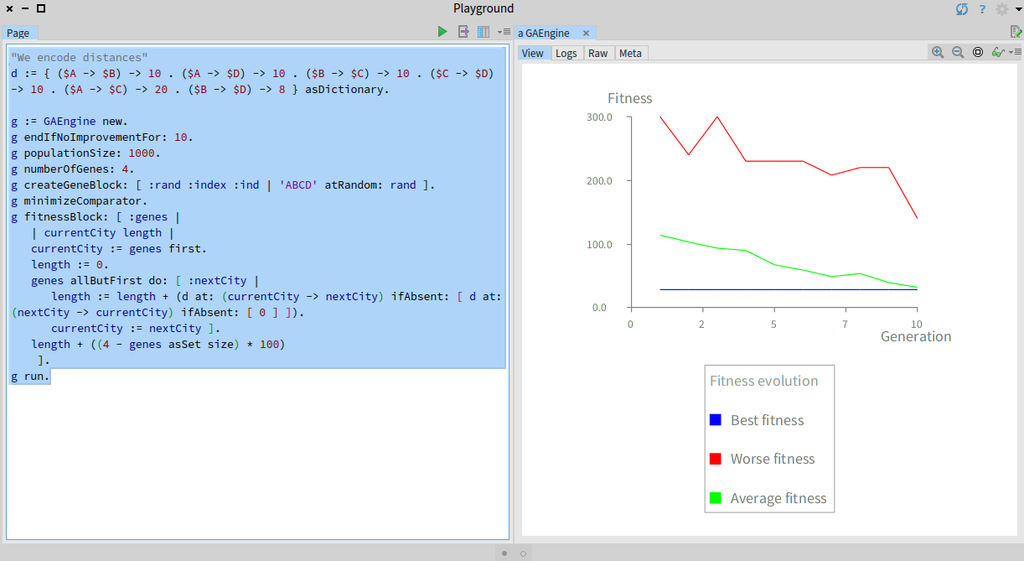

Figure 4: Improving the naive approach.

Let’s pick a larger example. The following script replaces our list of cities by a list of points:

```
"We encode distances"
points := {(100@160). (20@40). (60@20). (180@100). (200@40). (60@200). (80@180). (40@120). (140@180). (140@140). (20@160). (200@160). (180@60). (100@120). (120@80). (100@40). (20@20). (60@80). (180@200). (160@20)}.

g := GAEngine new.
g endIfNoImprovementFor: 60.
g populationSize: 1000.
g numberOfGenes: points size.
g createGeneBlock: [ :rand :index :ind | points atRandom: rand ].
g minimizeComparator.
g fitnessBlock: [ :genes |
        | distance d |
        distance := 0.
        2 to: genes size do: [ :pointIndex |
            d := (genes at: pointIndex) dist: (genes at: pointIndex - 1).
            distance := distance + d ].
        distance + ((points size - genes asSet size) * 1000) ].
g run.
```

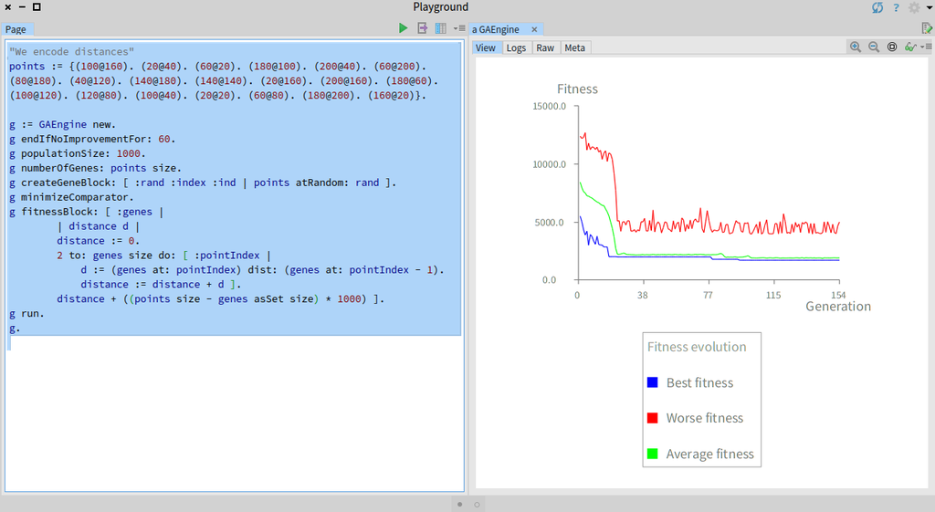

Figure 5: Improving the naive approach.

The distance is computed using the `dist:` method, defined in the class `Point`. Result of the script is shown in Figure 5. It seems that the algorithm found a compelling solution since it has reached a plateau.

We can see the result using the script:

```
...
result := g result.
v := RTView new.
elements := RTEllipse new size: 10; color: Color red trans; elementsOn: result.
elements @ RTPopup.
v addAll: elements.
elements do: [ :e | e translateTo: e model ].
2 to: result size do: [ :index |
    | l |
    l := RTArrowedLine new color: Color blue; headOffset: 0.8.
    v add: (l edgeFrom: (v elementFromModel: (result at: index - 1)) to: (v elementFromModel: (result at: index))) ].
v
```

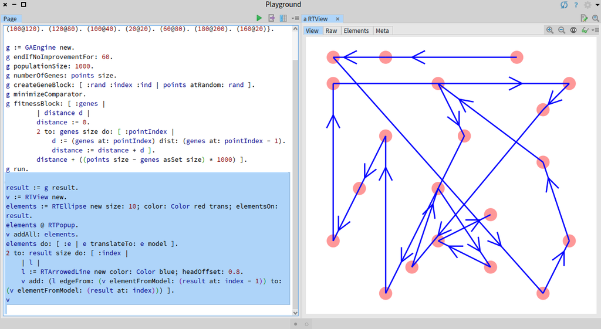

Figure 6: Visualizing the result of the naive approach.

Figure 6 gives the result of the algorithm. Obviously, the blue arrowed line does not indicate the shortest path that connect all the cities. For example, there are two close cities in the top-left which are not connected. An optimal solution should surely pass through these two cities, but the result of the algorithm does not take advance of this.

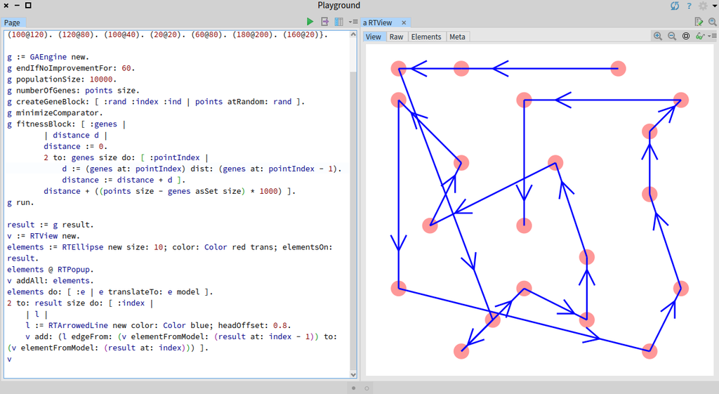

Figure 7: Result of a 10K population using the naive approach.

What if we increase the population size? Figure 7 shows the result of the same algorithm with a population large of 10 000 individuals. The result is now apparently closer to the solution.

Such a problem should be easy to solve. So, why the genetic algorithm is struggling to? The reason is that the algorithm is fighting hard from avoiding redundant cities. Instead of looking for exploring the set of possible valid candidates, the algorithm is actually struggling at identifying what are these valid candidates. This is why we label our solution as *naive*. Introducing a penalty as a way to guide the algorithm has a very negative side effect, which is looking for individual who do not suffer from this penalty, thus leaving little room for exploring valid path.

The morale of the story is that we should use the algorithm to explore valid path, and not using it to identify what these valid paths are. Remember the Murphy law? If the algorithm generates random paths, then it will surely has to deal with the randomly-generated mess. Instead of using the penalty, we should tune the algorithm in such a way that only valid path can be generated both in the initial population and as a result of the genetic operations.

## 1.4 Adequate Genetic Operations

Using our four-city primary example, consider the paths ABCD and DCBA. Any genetic operation, either a crossover between these two paths or a genetic mutation on any of it will generate an invalid path.

Can we design some genetic operations that do not produce invalid path? The answer is *yes*. The remaining of the chapter will present the *swap mutation operation* and the *ordered crossover operation*.

## 1.5 Swap Mutation Operation

Instead of replacing any gene any another one, as implemented by the `GAMutationOperation` class, we will *swap* two genes in an individual. For example, if we have ABCD, then a swap mutation could produce CBAD, but never AACD.

Luckily, we prepared the ground to implement new operation. We can define the class `GASwapMutationOperation`:

```
GAAbstractMutationOperation subclass: #GASwapMutationOperation
    instanceVariableNames: ''
    classVariableNames: ''
    poolDictionaries: ''
    category: 'GeneticAlgorithm-Core'
```

We can override the method `doMutate:` to swap genes:

```
GASwapMutationOperation>>doMutate: individual
    "Mutate genes of the argument"

    | i2 tmp |
    self checkForRandomNumber.
    1 to: individual genes size do: [ :i1 |
        self randomNumber <= mutationRate
            ifTrue: [
                i2 := random nextInt: individual genes size.
                tmp := individual genes at: i1.
                individual genes at: i1 put: (individual genes at: i2).
                individual genes at: i2 put: tmp ] ]
```

The method randomly pick to gene indexes, and swap their content.

## 1.6 Ordered Crossover Operation

We create the class `GAOrderedCrossoverOperation`:

```
GAAbstractCrossoverOperation subclass: #GAOrderedCrossoverOperation
    instanceVariableNames: ''
    classVariableNames: ''
    poolDictionaries: ''
    category: 'GeneticAlgorithm-Core'
```

The crossover will randomly choose the two extremities of the swath:

```
GAOrderedCrossoverOperation>>crossover: individualA with: individualB
    "Return a new child, which is the result of mixing the two individuals"
    | i1 i2 |
    i1 := self pickCutPointFor: individualA.
    i2 := self pickCutPointFor: individualA.

    (i1 > i2) ifTrue: [ | t | t := i1. i1 := i2. i2 := t ].
    ^ self crossover: individualA with: individualB from: i1 to: i2
```

The core of the ordered crossover operation is the method:

```
GAOrderedCrossoverOperation>>crossover: individualA with: individualB from: i1 to: i2
    "Return a new child, which is the result of mixing myself the two individual"

    | child crossOverGenes runningIndex swath |
    child := GAIndividual new.
    child random: random.

    swath := individualA genes copyFrom: i1 to: i2.
    crossOverGenes := Array new: individualA genes size.
    crossOverGenes := crossOverGenes copyReplaceFrom: i1 to: i2 with: swath.

    runningIndex := 1.
    (individualB genes copyWithoutAll: swath)
        do: [ :v | (crossOverGenes includes: v) ifFalse: [
                [(crossOverGenes at: runningIndex) notNil] whileTrue: [ runningIndex := runningIndex + 1 ].
                crossOverGenes at: runningIndex put: v ] ].

    child genes: crossOverGenes.
    ^ child
```

We used then the following utility method:

```
GAOrderedCrossoverOperation>>pickCutPointFor: partner
    "Simply return a random number between 1 and the number of genes of the individual provided as argument"
    ^ random nextInt: partner genes size
```

And *voila*! We can now test our new operator:

```
TestCase subclass: #GAOrderedCrossoverOperationTest
    instanceVariableNames: 'i1 i2 op'
    classVariableNames: ''
    poolDictionaries: ''
    category: 'GeneticAlgorithm-Tests'
```

We define a `setUp` method:

```
GAOrderedCrossoverOperationTest>>setUp
    super setUp.
    i1 := GAIndividual new genes: #(8 4 7 3 6 2 5 1 9 0).
    i2 := GAIndividual new genes: #(0 1 2 3 4 5 6 7 8 9).
    op := GAOrderedCrossoverOperation new.
```

A first test could be:

```
GAOrderedCrossoverOperationTest>>testCrossover1
    | i3 |
    i3 := op crossover: i1 with: i2 from: 4 to: 8.
    self assert: i3 genes equals: #(0 4 7 3 6 2 5 1 8 9).
```

We take the first gene as an extremity:

```
GAOrderedCrossoverOperationTest>>testCrossover2
    | i3 |
    i3 := op crossover: i1 with: i2 from: 1 to: 4.
    self assert: i3 genes equals: #(8 4 7 3 0 1 2 5 6 9).
```

We consider the last two genes as the swath:

```
GAOrderedCrossoverOperationTest>>testCrossover3
    | i3 |
    i3 := op crossover: i1 with: i2 from: 9 to: 10.
    self assert: i3 genes equals: #(1 2 3 4 5 6 7 8 9 0).
```

## 1.7 Our Large Example

At the beginning of the chapter we presented a configuration for which our naive approach could not find the shortest path. Now that we have defined our two new genetic operations, we can hook them up:

```
"We define the points"
points := {(100@160). (20@40). (60@20). (180@100). (200@40). (60@200). (80@180). (40@120). (140@180). (140@140). (20@160). (200@160). (180@60). (100@120). (120@80). (100@40). (20@20). (60@80). (180@200). (160@20)}.

g := GAEngine new.
g endIfNoImprovementFor: 5.
g populationSize: 1000.
g numberOfGenes: points size.
g crossoverOperator:  GAOrderedCrossoverOperation new.
g beforeCreatingInitialIndividual:
        [ :rand | points copy shuffleBy: rand ].
g mutationOperator: GASwapMutationOperation new.
g createGeneBlock: [ :rand :index :ind | points at: index ].

g minimizeComparator.
g fitnessBlock: [ :genes |
    | distance d |
    distance := 0.
    2 to: genes size do: [ :pointIndex |
        d := (genes at: pointIndex) dist: (genes at: pointIndex - 1).
        distance := distance + d ].
    distance ].
g run.
```

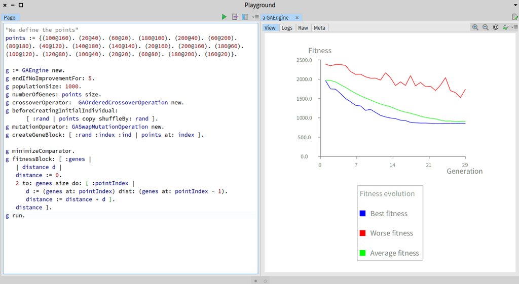

Figure 8: Result of using our two new genetic operators.

Figure 8 illustrates the evolution of the fitness along the generations. We configured the algorithm to stop if it does not find an improvement for 5 generations, using the message `endIfNoImprovementFor: 5`.

We can now visualize the result using:

```
...
result := g result.
v := RTView new.
elements := RTEllipse new size: 10; color: Color red trans; elementsOn: result.
elements @ RTPopup.
v addAll: elements.
elements do: [ :e | e translateTo: e model ].
2 to: result size do: [ :index |
    | l |
    l := RTArrowedLine new color: Color blue; headOffset: 0.8.
    v add: (l edgeFrom: (v elementFromModel: (result at: index - 1)) to: (v elementFromModel: (result at: index))) ].
v
```

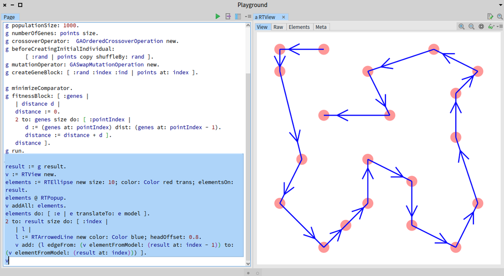

Figure 9: Result of using our two new genetic operators.

Figure 9 shows the result of the algorithm. With only a population large of 1 000 individuals, our algorithm was able to solve the TSP. Remember that with our first naive approach, we could not solve it with a population ten times larger!

## 1.8 What have we seen in this chapter?

This chapter presented a compelling way to solve a complex problem by using dedicated genetic operations. In particular, the chapters presented

- the traveler salesman problem, a classical algorithmic problem;
- an illustration of the consequence of naively applying the genetic algorithm;
- a motivation for introducing two new genetic operations, namely the *swap mutation operation* and the *ordered crossover operation*.